# 线性回归：岗位招聘

李哲 zheli20@fudan.edu.cn

2022年3月21日

## 一、清除工作环境

```r
# 清除工作环境
cat("\014");rm(list=ls())
```

```r
# 设置工作目录
setwd("~/Downloads/代码课0321")
# 加载所需要的包
library(ggplot2)
library(dplyr)
```

## 二、读取数据

- 读取数据

```r
jobinfo <- read.csv("jobinfo_ch7.csv", fileEncoding = "utf-8")
```

- 数据概况

```r
head(jobinfo)
```

```
##   aveSalary R SPSS Excel Python MATLAB Java SQL SAS Stata EViews Spark Hadoop
## 1   19999.5 1    0     0      0      0    0   0   1     0      0     0      0
## 2   19500.0 0    0     0      0      0    0   0   0     0      0     0      0
## 3   19499.0 0    0     0      1      0    0   1   0     0      0     0      1
## 4   19000.0 0    1     1      0      1    0   1   0     0      0     0      0
## 5   19000.0 0    1     1      0      1    0   1   0     0      0     0      0
## 6   19000.0 0    0     0      0      0    0   0   0     0      0     0      0
##   公司类别    公司规模 学历要求 工作经验   地区
## 1     国企 1000-5000人     本科        2 北上深
## 2 民营公司 1000-5000人     本科        2 北上深
## 3 民营公司    50-500人     本科        3 北上深
## 4 民营公司    50-500人     本科        3 北上深
## 5 民营公司    50-500人     本科        3 北上深
## 6 民营公司    50-500人     大专        0 北上深
```

```r
summary(jobinfo)
```

```
##    aveSalary           R                SPSS             Excel
##  Min.   : 1500   Min.   :0.00000   Min.   :0.00000   Min.   :0.0000
##  1st Qu.: 5250   1st Qu.:0.00000   1st Qu.:0.00000   1st Qu.:0.0000
##  Median : 7000   Median :0.00000   Median :0.00000   Median :0.0000
##  Mean   : 8048   Mean   :0.06181   Mean   :0.07962   Mean   :0.2148
##  3rd Qu.:10000   3rd Qu.:0.00000   3rd Qu.:0.00000   3rd Qu.:0.0000
##  Max.   :20000   Max.   :1.00000   Max.   :1.00000   Max.   :1.0000
##      Python          MATLAB             Java              SQL
##  Min.   :0.000   Min.   :0.00000   Min.   :0.00000   Min.   :0.00000
##  1st Qu.:0.000   1st Qu.:0.00000   1st Qu.:0.00000   1st Qu.:0.00000
##  Median :0.000   Median :0.00000   Median :0.00000   Median :0.00000
##  Mean   :0.044   Mean   :0.01975   Mean   :0.03233   Mean   :0.09713
##  3rd Qu.:0.000   3rd Qu.:0.00000   3rd Qu.:0.00000   3rd Qu.:0.00000
##  Max.   :1.000   Max.   :1.00000   Max.   :1.00000   Max.   :1.00000
##       SAS              Stata              EViews             Spark
##  Min.   :0.00000   Min.   :0.000000   Min.   :0.000000   Min.   :0.00000
##  1st Qu.:0.00000   1st Qu.:0.000000   1st Qu.:0.000000   1st Qu.:0.00000
##  Median :0.00000   Median :0.000000   Median :0.000000   Median :0.00000
##  Mean   :0.07049   Mean   :0.002394   Mean   :0.002095   Mean   :0.01317
##  3rd Qu.:0.00000   3rd Qu.:0.000000   3rd Qu.:0.000000   3rd Qu.:0.00000
##  Max.   :1.00000   Max.   :1.000000   Max.   :1.000000   Max.   :1.00000
##      Hadoop          公司类别           公司规模           学历要求
##  Min.   :0.00000   Length:6682        Length:6682        Length:6682
##  1st Qu.:0.00000   Class :character   Class :character   Class :character
##  Median :0.00000   Mode  :character   Mode  :character   Mode  :character
##  Mean   :0.02559
##  3rd Qu.:0.00000
##  Max.   :1.00000
##     工作经验          地区
##  Min.   : 0.000   Length:6682
##  1st Qu.: 0.000   Class :character
##  Median : 1.000   Mode  :character
##  Mean   : 1.665
##  3rd Qu.: 3.000
##  Max.   :10.000
```

## 三、探索性分析

### 1. 因变量

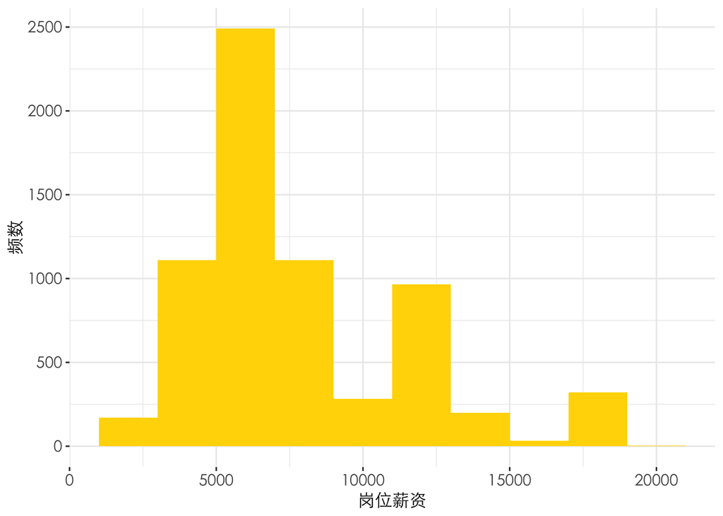

```r
ggplot(data = jobinfo,aes(x=aveSalary)) +
    geom_histogram(binwidth = 2000,fill="gold") +
    labs(y="频数",x = "岗位薪资") +
    theme_bw() +
    theme(panel.border=element_blank(),
          text = element_text(family = "STXihei"),
          # axis.title.x = element_text(size = 12),
          axis.title = element_text(size = 12),
          axis.text = element_text(size = 11))
```

```r
    # theme_classic()
```

### 2. 自变量

薪资的影响因素有很多，诸如：学历、公司规模、工作年限等。了解这些因素对于薪资的影响有助于求职者找准提升空间。

#### 2.1 学历影响

我们以**学历**为例，探究学历对于薪资有什么影响呢？在同一张图中绘制各类学历的对数平均薪资箱线图：

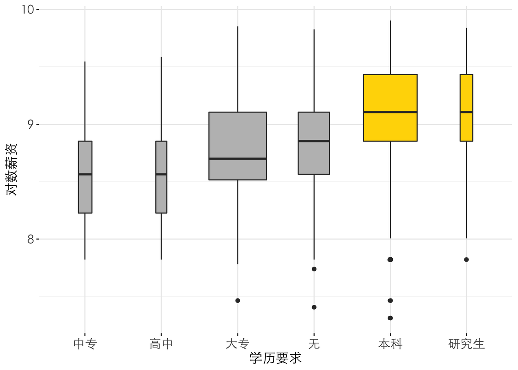

```r
# 利用箱线图画出，学历vs对数平均薪资的分布，箱体的宽度越宽表示样本量越多
# 将学历转化为因子型变量，便于画图
jobinfo$学历要求 = factor(jobinfo$学历要求,levels=c("中专","高中","大专","无","本科","研究生"))
jobinfo$对数薪资 <- log(jobinfo$aveSalary)
# 绘制箱线图
ggplot(jobinfo,aes(学历要求,对数薪资)) +
        geom_boxplot(varwidth = TRUE, fill = c(rep("grey",4),rep("gold",2))) +
        labs(x="学历要求", y = "对数薪资")+
    theme_bw() +
    theme(panel.border=element_blank(),
          text = element_text(family = "STXihei"),
        axis.title = element_text(size = 13),
          axis.text = element_text(size = 12))
```

```r
    # theme_classic()
```

```r
tmp <- jobinfo %>% group_by(学历要求) %>% summarise(median(aveSalary))
tmp
```

```
## # A tibble: 6 x 2
##   学历要求 `median(aveSalary)`
##   <fct>                  <dbl>
## 1 中专                   5250.
## 2 高中                   5250.
## 3 大专                   6000
## 4 无                     7000.
## 5 本科                   9000.
## 6 研究生                 9000.
```

#### 2.2 数据分析软件影响

数据分析岗位的工作固然避免不了数据分析软件的使用。我们以`Python`和`SPSS`为例，用箱线图分析软件需求对薪资的影响。

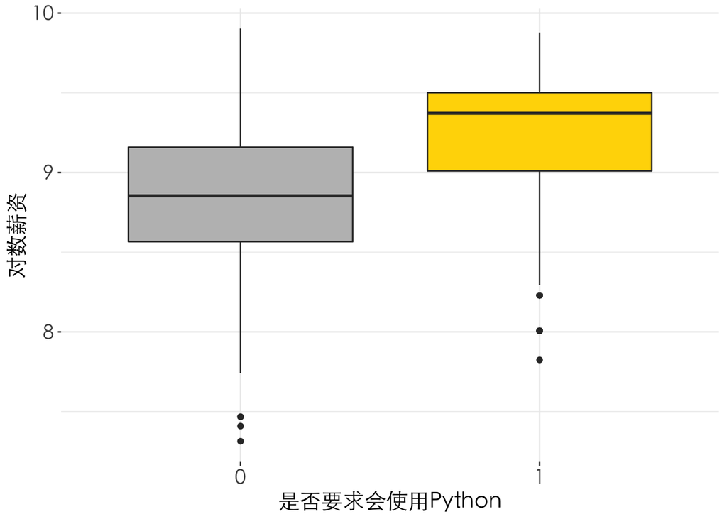

```r
ggplot(jobinfo,aes(as.factor(Python),对数薪资)) +
        geom_boxplot(fill = c("grey","gold")) +
        labs(x="是否要求会使用Python", y = "对数薪资") +
            theme_bw() +
theme(panel.border=element_blank(),
      text = element_text(family = "STXihei"),
                      axis.title = element_text(size = 15),
          axis.text = element_text(size = 14))
```

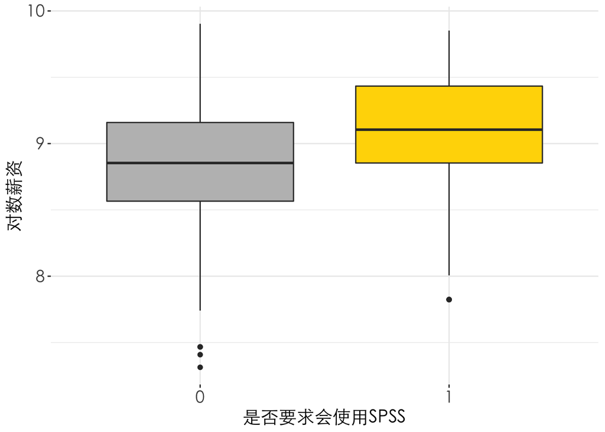

```r
        # theme_classic()
ggplot(jobinfo,aes(as.factor(SPSS),对数薪资)) +
        geom_boxplot(fill = c("grey","gold")) +
        labs(x="是否要求会使用SPSS", y = "对数薪资") +
            theme_bw() +
theme(panel.border=element_blank(),
      text = element_text(family = "STXihei"),
                      axis.title = element_text(size = 15),
          axis.text = element_text(size = 14))
```

```r
        # theme_classic()
```

## 四、建立回归方程

### 1. 以平均薪资为因变量的线性模型

```r
# 转换为factor型变量，地区以河北为基准，公司类别以国企为基准，公司规模以少于50人为基准，学历以无为基准
jobinfo$公司类别 <- factor(jobinfo$公司类别, levels = c("国企","合资","外资","上市公司","民营公司","创业公司"))
jobinfo$公司规模 <- factor(jobinfo$公司规模, levels = c("少于50人","50-500人","500-1000人","1000-5000人","5000-10000人","10000人以上"))
jobinfo$学历要求 <- factor(jobinfo$学历要求, levels = c("无","中专","高中","大专","本科","研究生"))

## 软件要求
for (i in c(2:13)){
        jobinfo[,i] <- as.factor(jobinfo[,i])
}
```

```r
## 建立线性模型
lm.fit1 = lm(aveSalary ~ ., data = jobinfo)
## 查看回归结果
summary(lm.fit1)
```

```
##
## Call:
## lm(formula = aveSalary ~ ., data = jobinfo)
##
## Residuals:
##     Min      1Q  Median      3Q     Max
## -1865.1  -641.6  -195.7   273.3  5554.5
##
## Coefficients:
##                        Estimate Std. Error  t value Pr(>|t|)
## (Intercept)          -62896.002    276.009 -227.877  < 2e-16 ***
## R1                      205.761     64.776    3.176  0.00150 **
## SPSS1                   -19.360     61.723   -0.314  0.75379
## Excel1                  -34.835     29.203   -1.193  0.23297
## Python1                  54.765     69.774    0.785  0.43255
## MATLAB1                 -27.048     89.889   -0.301  0.76350
## Java1                    12.031     76.836    0.157  0.87558
## SQL1                    102.489     44.272    2.315  0.02064 *
## SAS1                    -40.231     67.461   -0.596  0.55095
## Stata1                  -82.045    241.677   -0.339  0.73426
## EViews1                 102.239    250.519    0.408  0.68321
## Spark1                  298.702    129.670    2.304  0.02128 *
## Hadoop1                 306.007     98.323    3.112  0.00186 **
## 公司类别合资             30.636     70.275    0.436  0.66289
## 公司类别外资             87.686     69.557    1.261  0.20748
## 公司类别上市公司          4.525     78.609    0.058  0.95410
## 公司类别民营公司         44.787     62.779    0.713  0.47562
## 公司类别创业公司         66.105    119.654    0.552  0.58065
## 公司规模50-500人          5.570     33.069    0.168  0.86625
## 公司规模500-1000人      -63.772     44.522   -1.432  0.15209
## 公司规模1000-5000人      74.593     46.486    1.605  0.10862
## 公司规模5000-10000人    -25.742     82.536   -0.312  0.75513
## 公司规模10000人以上     -56.940     68.158   -0.835  0.40351
## 学历要求中专            165.548     81.233    2.038  0.04160 *
## 学历要求高中            149.668     94.822    1.578  0.11452
## 学历要求大专              6.266     36.342    0.172  0.86312
## 学历要求本科             53.284     37.719    1.413  0.15780
## 学历要求研究生          123.529     85.359    1.447  0.14790
## 工作经验                 10.605      7.311    1.450  0.14700
## 地区非北上深            465.629     32.353   14.392  < 2e-16 ***
## 对数薪资               7958.636     30.330  262.403  < 2e-16 ***
## ---
## Signif. codes:  0 '***' 0.001 '**' 0.01 '*' 0.05 '.' 0.1 ' ' 1
##
## Residual standard error: 921.6 on 6651 degrees of freedom
## Multiple R-squared:  0.9401, Adjusted R-squared:  0.9398
## F-statistic:  3479 on 30 and 6651 DF,  p-value: < 2.2e-16
```

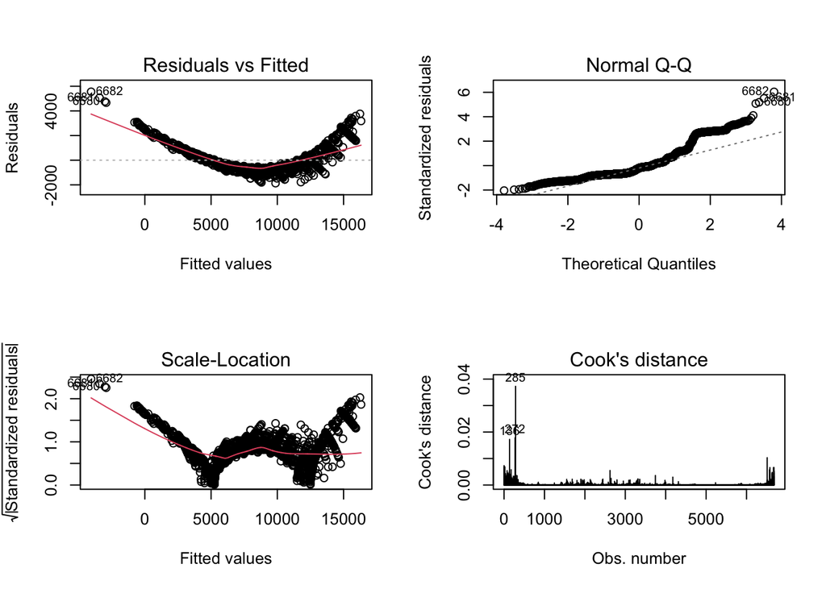

```r
## 对线性模型进行回归诊断
# 将画布分为2*2的4块
par(mfrow=c(2,2))
plot(lm.fit1, which = c(1:4))
```

### 2. 以对数平均薪资为因变量的线性模型

```r
## 计算对数因变量
jobinfo$对数薪资 <- log(jobinfo$aveSalary)
# 建立对数线性模型，剔除平均薪资变量
lm.fit2 = lm(对数薪资 ~ .-aveSalary, data = jobinfo)
## 查看回归结果
summary(lm.fit2)
```

```
##
## Call:
## lm(formula = 对数薪资 ~ . - aveSalary, data = jobinfo)
##
## Residuals:
##      Min       1Q   Median       3Q      Max
## -1.59999 -0.26299 -0.02898  0.25620  1.43210
##
## Coefficients:
##                       Estimate Std. Error t value Pr(>|t|)
## (Intercept)           8.753373   0.030511 286.892  < 2e-16 ***
## R1                    0.032774   0.026183   1.252  0.21071
## SPSS1                 0.055665   0.024942   2.232  0.02566 *
## Excel1               -0.117507   0.011717 -10.029  < 2e-16 ***
## Python1               0.083433   0.028188   2.960  0.00309 **
## MATLAB1              -0.006056   0.036338  -0.167  0.86765
## Java1                 0.069968   0.031050   2.253  0.02426 *
## SQL1                  0.147355   0.017806   8.276  < 2e-16 ***
## SAS1                  0.046839   0.027265   1.718  0.08586 .
## Stata1               -0.123253   0.097687  -1.262  0.20710
## EViews1               0.039811   0.101272   0.393  0.69425
## Spark1               -0.037998   0.052417  -0.725  0.46853
## Hadoop1               0.179699   0.039686   4.528 6.06e-06 ***
## 公司类别合资          0.087100   0.028389   3.068  0.00216 **
## 公司类别外资          0.025907   0.028117   0.921  0.35686
## 公司类别上市公司      0.074514   0.031765   2.346  0.01902 *
## 公司类别民营公司      0.041935   0.025373   1.653  0.09844 .
## 公司类别创业公司      0.103932   0.048354   2.149  0.03164 *
## 公司规模50-500人      0.034777   0.013361   2.603  0.00927 **
## 公司规模500-1000人    0.017690   0.017997   0.983  0.32567
## 公司规模1000-5000人   0.044287   0.018784   2.358  0.01842 *
## 公司规模5000-10000人  0.045901   0.033361   1.376  0.16890
## 公司规模10000人以上   0.048603   0.027546   1.764  0.07771 .
## 学历要求中专         -0.200786   0.032746  -6.132 9.20e-10 ***
## 学历要求高中         -0.223217   0.038234  -5.838 5.53e-09 ***
## 学历要求大专         -0.117711   0.014620  -8.051 9.64e-16 ***
## 学历要求本科          0.090812   0.015207   5.972 2.47e-09 ***
## 学历要求研究生        0.201236   0.034418   5.847 5.25e-09 ***
## 工作经验              0.084425   0.002769  30.495  < 2e-16 ***
## 地区非北上深         -0.374549   0.012246 -30.585  < 2e-16 ***
## ---
## Signif. codes:  0 '***' 0.001 '**' 0.01 '*' 0.05 '.' 0.1 ' ' 1
##
## Residual standard error: 0.3725 on 6652 degrees of freedom
## Multiple R-squared:  0.3476, Adjusted R-squared:  0.3448
## F-statistic: 122.2 on 29 and 6652 DF,  p-value: < 2.2e-16
```

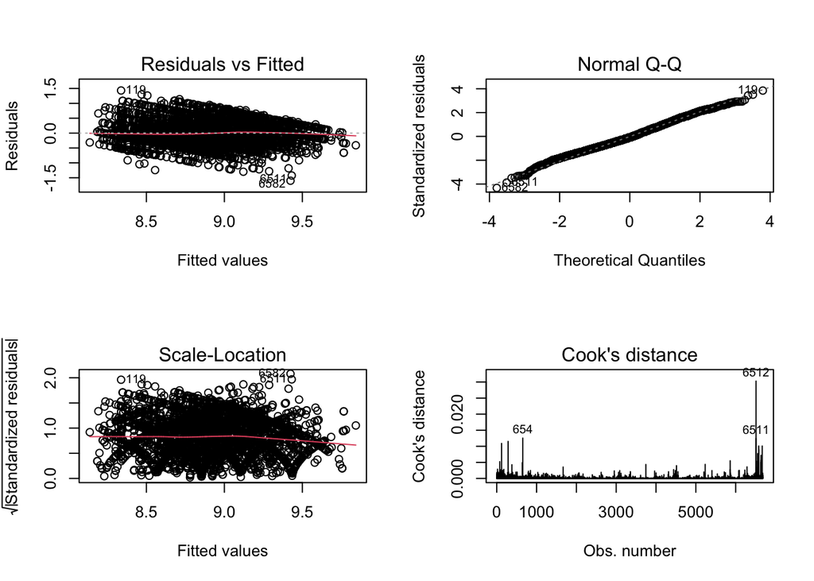

```r
# 将画布分为2*2的4块
par(mfrow=c(2,2))
plot(lm.fit2, which = c(1:4))
```

- 图中所示残差并不随着拟合值的变化呈现规律性变化，因此基本满足线性假设
- 图中的散点大部分落在呈45度倾斜的直线上，满足正态性
- 水平线周围的点应呈现无规律随机分布，不存在异方差问题
- 样本点的库克距离最大值未超过0.05，因此认为样本中不存在异常点

### 3. 多重共线性诊断

```r
# 多重共线性诊断：计算VIF值
library(DAAG)
vif(lm.fit2)
```

```
##                   R1                SPSS1               Excel1
##               1.9138               2.1948               1.1146
##              Python1              MATLAB1                Java1
##               1.6090               1.2310               1.4519
##                 SQL1                 SAS1               Stata1
##               1.3385               2.3449               1.0974
##              EViews1               Spark1              Hadoop1
##               1.0323               1.7191               1.8908
##         公司类别合资         公司类别外资     公司类别上市公司
##               3.5698               3.7260               2.3917
##     公司类别民营公司     公司类别创业公司     公司规模50-500人
##               6.6519               1.3644               2.1190
##   公司规模500-1000人  公司规模1000-5000人 公司规模5000-10000人
##               1.6593               1.6808               1.1451
##  公司规模10000人以上         学历要求中专         学历要求高中
##               1.2954               1.1550               1.1191
##         学历要求大专         学历要求本科       学历要求研究生
##               2.5233               2.6254               1.1862
##             工作经验         地区非北上深
##               1.0490               1.0905
```

**VIF<10**，推断不存在多重共线性

### 4. 模型选择

```r
## 使用BIC准则选择模型
n <- nrow(jobinfo)
lm.bic <- step(lm.fit2, direction = "both", k = log(n), trace = F)
summary(lm.bic)
```

```
##
## Call:
## lm(formula = 对数薪资 ~ SPSS + Excel + Python + SQL + Hadoop +
##     学历要求 + 工作经验 + 地区, data = jobinfo)
##
## Residuals:
##      Min       1Q   Median       3Q      Max
## -1.54248 -0.25992 -0.02571  0.25825  1.43138
##
## Coefficients:
##                 Estimate Std. Error t value Pr(>|t|)
## (Intercept)     8.827384   0.013680 645.276  < 2e-16 ***
## SPSS1           0.092435   0.018706   4.941 7.94e-07 ***
## Excel1         -0.117721   0.011646 -10.108  < 2e-16 ***
## Python1         0.110596   0.024510   4.512 6.53e-06 ***
## SQL1            0.160374   0.017389   9.223  < 2e-16 ***
## Hadoop1         0.191131   0.030947   6.176 6.96e-10 ***
## 学历要求中专   -0.202515   0.032791  -6.176 6.97e-10 ***
## 学历要求高中   -0.223880   0.038146  -5.869 4.60e-09 ***
## 学历要求大专   -0.116834   0.014630  -7.986 1.63e-15 ***
## 学历要求本科    0.094769   0.015130   6.263 4.00e-10 ***
## 学历要求研究生  0.201863   0.034147   5.912 3.56e-09 ***
## 工作经验        0.084348   0.002766  30.496  < 2e-16 ***
## 地区非北上深   -0.371999   0.011976 -31.061  < 2e-16 ***
## ---
## Signif. codes:  0 '***' 0.001 '**' 0.01 '*' 0.05 '.' 0.1 ' ' 1
##
## Residual standard error: 0.3732 on 6669 degrees of freedom
## Multiple R-squared:  0.3436, Adjusted R-squared:  0.3424
## F-statistic: 290.9 on 12 and 6669 DF,  p-value: < 2.2e-16
```

### 5. 模型预测

```r
## 新样本
testdata <- data.frame(R = 1, SPSS = 0, Excel = 0, Python = 1, MATLAB = 0, Java = 0, SQL = 1, SAS = 0, Stata = 0, EViews = 0, Spark = 0, Hadoop = 1, 公司类别 = "上市公司", 公司规模 = "1000-5000人", 学历要求 = "研究生", 工作经验 = 3, 地区 = "北上深")
## 将软件技能转换为factor类型
for (i in c(1:12)) {
    testdata[,i] <- as.factor(testdata[,i])
}
logsalary_hat <- predict(lm.bic, newdata = testdata)  # 预测值
sigma_hat2 <- sum(lm.bic$residuals^2)/lm.bic$df.residual  # sigma^2估计值
y_hat <- exp(logsalary_hat + sigma_hat2/2)  #
cat("平均薪资水平约为", round(y_hat, 2), "元/月")
```

```
## 平均薪资水平约为 18288.72 元/月
```

**注意：因为我们采用的是对数线性回归，因此预测值并不是**$e^{\hat{y}}$，而应该是
$$\hat y'=e^{\hat y + \frac{\hat \sigma^2}{2}}$$
其中
$$\hat\sigma^2=\frac{1}{n-p-1}\sum_{i=1}^n(\hat y_i-y_i^0)^2$$

## 五、交叉验证的实现

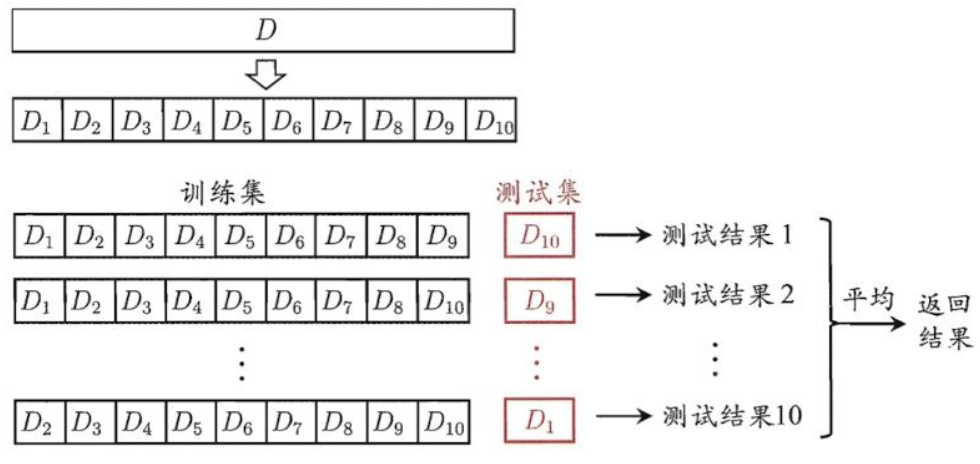

十折交叉验证示意图

很多第三方包都能实现交叉验证的功能，例如课件中`DAAG`包中的`cv.lm`函数，`bootstrap`包中的`crossval()`函数，当然自己自己造轮子也是比较简单的：

```r
pred.cv <- function(dat, k) {
  ind <- sample(1:k, nrow(dat), replace=T) # 重复放回抽样
  pred_cv <-rep(0, nrow(dat))
  for (i in 1:k) {
    ii  <- which(ind==i)
    obj <- lm(`对数薪资`~ . - aveSalary, data=dat[-ii,])
    pred_cv[ii] <- predict(obj, dat[ii,])
  }
  rmse <- sqrt(mean(pred_cv-dat$`对数薪资`)^2)
  return(list(pred_cv=pred_cv, rmse = rmse))
}
```

$$RMSE=\sqrt{\frac{1}{N}\sum_{i=1}^N(\hat y_i - y_i^0)^2}$$

```r
set.seed(2022)
system.time({pred_cv <- pred.cv(dat=jobinfo, k=5)})
```

```
##    user  system elapsed
##   0.084   0.003   0.088
```

```r
pred_cv$rmse
```

```
## [1] 1.048917e-05
```